# Percolation analysis of transect data

07 Juni, 2019

Abstract

## 0.1

## 0.2 different cluster analysis visualisation

Einladen der Daten und verbindung:

## 0.3 run analysis and save results of every run.

### 0.3.1 input in source _file.txt source_file,map_name,shape_file_name,DTM_file_name BefundesNL-minimal.csv, late neolithic features, alle_Schnitt-Fundstellen.shp,

source_file,map_name,shape_file_name,DTM_file_name BefundefBZ-minimal.csv, early bronze age features, alle_Schnitt-Fundstellen.shp,

source_file,map_name,shape_file_name,DTM_file_name BefundesBZ-minimal.csv, late bronze age features, alle_Schnitt-Fundstellen.shp,

source_file,map_name,shape_file_name,DTM_file_name BefundesBZ_aeEZ-minimal.csv, late bronze age to early iron age features, alle_Schnitt-Fundstellen.shp,

### 0.3.2 input in radius_values.txt (stays)

upper_radius,lower_radius,step_value,limit,upper_threshold,lower_threshold,radius_unit 500,2,1, 1000,0,0,1

## 0.4 run code (each time new after changing source_file.txt and saving results somewhere)

## 0.5 für vergleichende plots:

## 0.6 try new things

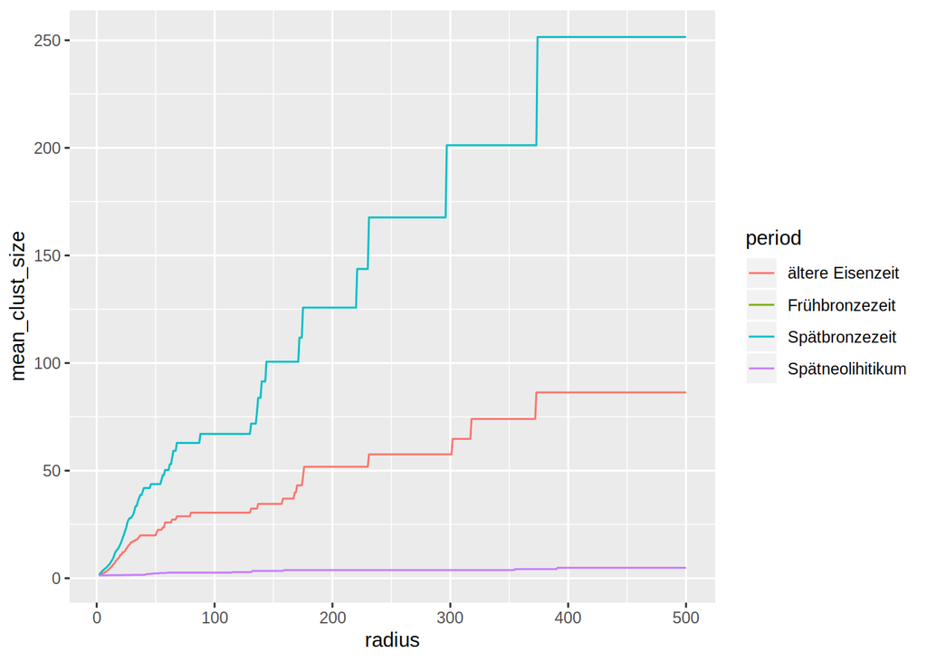

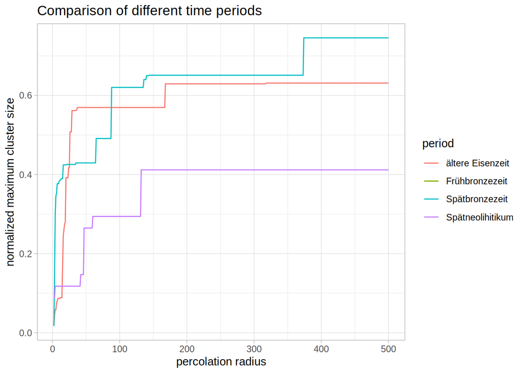

# auslesen der “knackpunkte”?

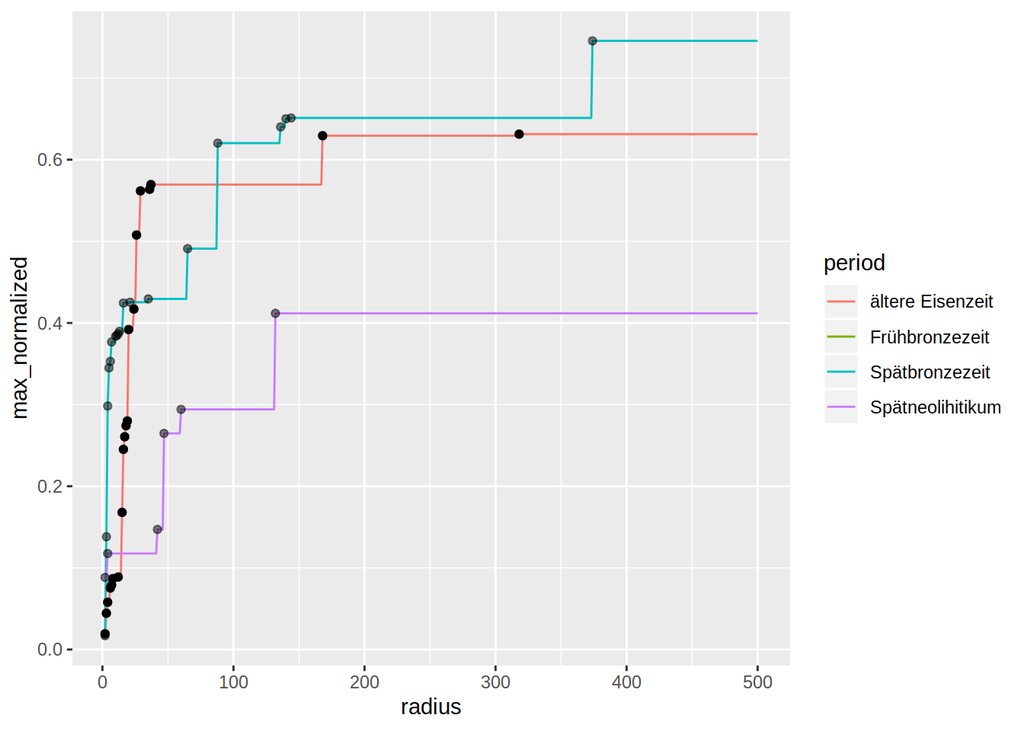

Die Points sind bereits wichtige Radii-Angaben, weil der URsprungsdatensatz ja auch einfach bei 1 = 1m anfängt.

Welcher Knickpunkt ist wichtig? Wendepunkte berechnen:

## 0.7 Tabelle anschauen

```
#> [1] 60
#> [1] 88
#> [1] 51
```

# 1 next point: Vergleich mit meinen density daten?

# 2 Idee: Daten einladen, teilen, etc, run source,

copied from old:

new:

# 3 Conclusion

# 4 Acknowledgements

# 5 References

### 5.0.1 Colophon